### 空間分析 實習7

#### 地理二 B06208001 龔泓愷

```r
library(rgdal)
library(spatstat)
School <- readOGR(dsn =  "./data", layer = "Schools", encoding="utf8")
```

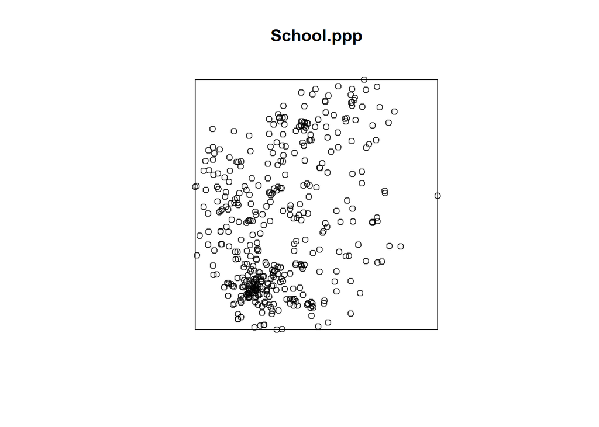

```r
# "ppp" data format for spatstat
bnd<-bbox(School) # get x, y limitation
x.coor<-School$coords.x1
y.coor<-School$coords.x2
x.range<-bnd[1,]
y.range<-bnd[2,]

# ppp(x.coordinates, y.coordinates, x.range, y.range)
School.ppp<-ppp(x.coor,y.coor,x.range,y.range)
plot(School.ppp)
```

> 1. Nearest Neighbor Disntance

### Step1

H0：台南學校各點和其最近點距離的平均，與隨機分布各點和其最近點距離的平均相同(分布型態為隨機)  
H1：台南學校各點和其最近點距離的平均，與隨機分布各點和其最近點距離的平均不同(分布型態不為隨機)  
雙尾檢定，顯著水準：0.1

### Step2

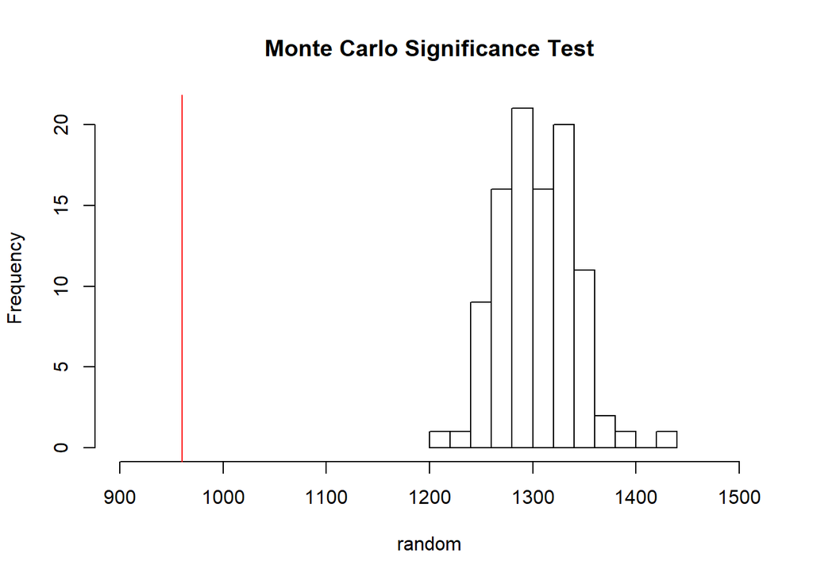

```r
# Nearest Neighborhood Distance
nnd<-nndist(School.ppp, k=1)
d1<-mean(nnd) # Tainan School

# Random point
TN.Windows<-owin(xrange=x.range, yrange=y.range) # set the windows of random points
random <- vector()
for (i in 1:99) {
  nn1<-rpoint(424, win=TN.Windows)
  nnd1<-nndist(nn1, k=1)
  random[i]<-mean(nnd1)
}

# Frequency plot
hist(random, main = "Monte Carlo Significance Test", xlim = c(900, 1500))
abline(v = d1, col = "red")
```

### Step3

```r
# Get no.5, no.95
random <- sort(random)
nnd.5 <- random[5]
nnd.95 <- random[95]
d1 < nnd.5|d1 > nnd.5
```

```
## [1] TRUE
```

p_value < 0.1

### Step4

在顯著水準為0.1的情況下，因為p_value < 0.1，拒絕虛無假說

### Step5

在顯著水準為0.1的情況下，呈現統計上顯著，因此能下“台南學校的點分布型態不為隨機”的結論

> 2. K-order Nearest Neighbor Indices

### Step1

H0：台南學校各點和其前100近的點距離的平均，與隨機分布與其前100近的點距離的平均相同(分布型態為隨機)  
H1：台南學校各點和其前100近的點距離的平均，與隨機分布與其前100近的點距離的平均不同(分布型態不為隨機)  
雙尾檢定，顯著水準0.1

### Step2

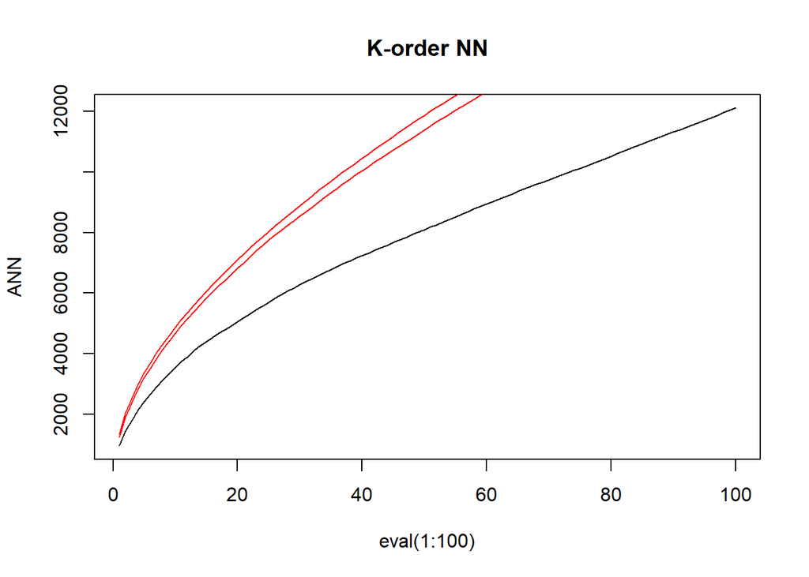

```r
# K-order Nearest Neighbor Indices
ANN <- apply(nndist(School.ppp, k=1:100),2,FUN=mean)
nni <- ANN #先讓他有一個值，待會直接cbind

for (i in 1:99) {
  nn1<-rpoint(424, win=TN.Windows)
  nni1<-apply(nndist(nn1, k=1:100),2,FUN=mean)
  nni<-cbind(nni, nni1)
}

nni.5 <- vector()
nni.95 <- vector()
for (i in 1:100) {
  nni.5[i] <- sort(nni[i,])[5]
  nni.95[i] <- sort(nni[i,])[95]
}

plot(ANN ~ eval(1:100), type="l", main="K-order NN" )
lines(nni.5 ~ eval(1:100), type="l",col="red")
lines(nni.95 ~ eval(1:100), type="l",col="red")
```

### Step3

設定顯著水準為0.1，上圖第一條紅線為第95百分位數，第二條紅線為第5百分位數，可以見到黑線遠小於第5百分位數，並落在拒絕區間(沒有被包住)。

### Step4

在顯著水準為0.1的情況下，因為黑線落在拒絕區間，因此拒絕虛無假說

### Step5

在顯著水準為0.1的情況下，呈現統計上顯著，因此能下“台南學校的點分布型態不為隨機”的結論

> 3. G Function

### Step1

H0：台南學校的點分布型態為隨機  
H1：台南學校的點分布型態不為隨機  
雙尾檢定，顯著水準0.1

### Step2

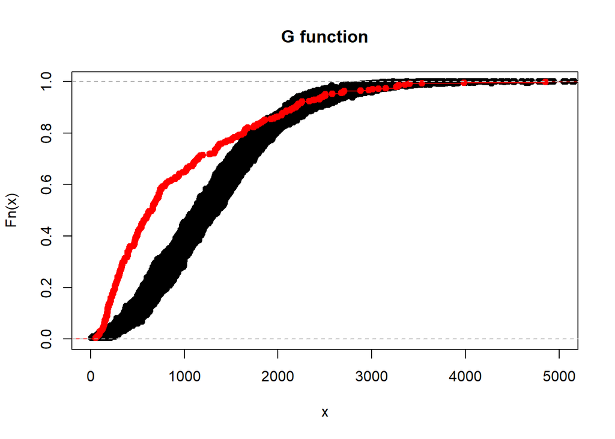

```r
# G(d)function
G.nnd <- ecdf(nnd)
plot(G.nnd, main="G function",xlim=c(0,5000),col="red")

for (i in 1:99) {
  nn1<-rpoint(424, win=TN.Windows)
  nnd<-nndist(nn1, k=1)
  G.ran<-ecdf(nnd)
  lines(G.ran, main="G function",xlim=c(0,5000))
}

lines(G.nnd, main="G function",xlim=c(0,5000),col="red") #被蓋掉了
```

### Step3

設定顯著水準為0.1，可以看到紅線起初成長的速度相當快，落在拒絕區間(沒有被包住)

### Step4

在顯著水準為0.1的情況下，因為紅線落在拒絕區間，因此拒絕虛無假說

### Step5

在顯著水準為0.1的情況下，呈現統計上顯著，因此能下“台南學校的點分布型態不為隨機”的結論